# Data Products Presentation

17/09/2021

## Introduction to the App…

**Ever wondered which advertising channel can help achieve more sales…. the following app could help!**

### The Project

- The developing data products application uses Shiny to create an application which helps to solve this question
- There is an interavtive application hosted on ShinyApps.io and the Github page which contains all the underlying code

### The App

- The applcation focusses on analysing company sales revenue given the spend on difference marketing channels; specifically on newspaper advertising, youtube or facebook
- The app allows the user to select the advertising type in order to display a plot of sales versus advertising spend including a regression line
- A slider allows the user to enter an advertising spend for a given channel and returns the predicted sales revenue it would generate

## Visualising the Data…

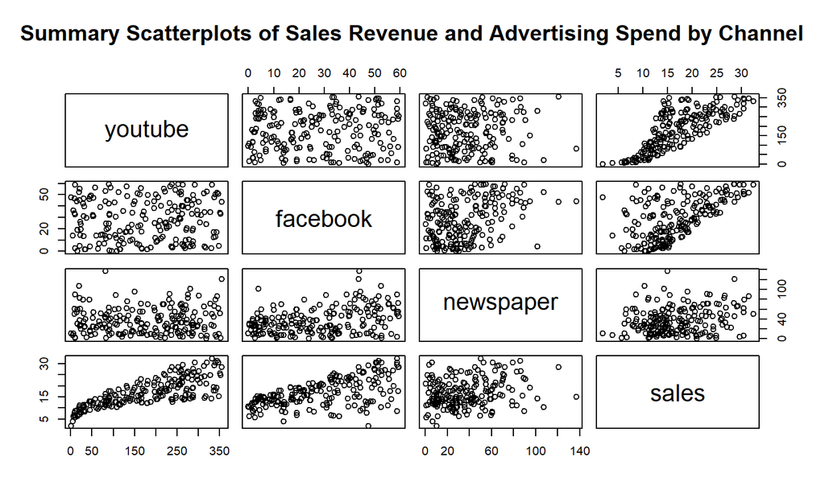

```r
library(datarium)
library(ggplot2)
data("marketing", package = "datarium")
plot(marketing, main = "Summary Scatterplots of Sales Revenue and Advertising Spend by Channel")
```

## The Server Calculation…

- Below is the Server Calculation within the App, users can change the dropdown to visualise the sales revenue and predict sales for a given advertising spend

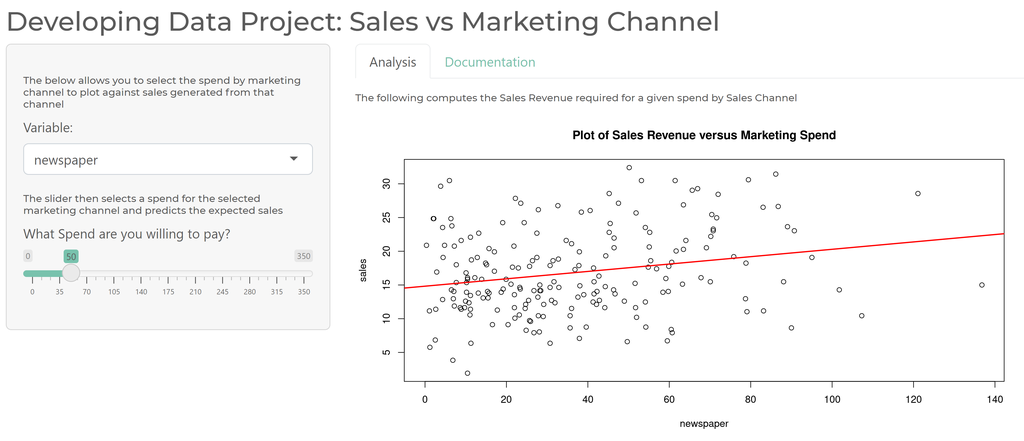

## Where can I find the App…

**Please download and use the app!**

- The application can be run from the following address: https://ma3pab.shinyapps.io/Marketing_Spend_Application/
- The underlying source code for replication can be found here on github: https://github.com/ma3pab/Developing_Data_Products